# Kaggle: Bike Trips

Romario

2023-01-31

# Introdução

Serem acusados de fazerem mal ao [meio-ambiente](https://www.meucarronovo.com.br/blog/post/Conheca-quais-sao-os-impactos-do-automovel-no-meio-ambiente/) e terem um [aumento](https://inteligenciafinanceira.com.br/aprenda/poupar/custo-para-manter-o-carro-quase-dobra-em-sete-anos-avalie-se-e-hora-de-trocar-o-seu/), quase logarítmico, dos custos com impostos e manutenção, tornaram os carros cada vez mais impopulares.

Em contrapartida, vem aumentando o uso de aplicativos de mobilidade, [individual](https://www.tecmundo.com.br/software/215160-conheca-aplicativos-transporte-parecidos-uber.htm) e [coletiva](https://canaltech.com.br/mercado/buser-wemobi-e-flixbus-a-disputa-dos-ubers-dos-onibus-engata-a-quinta-marcha-193512/). Tanto de automóveis, como de patinetes e bicicletas.

Aqui no Rio, cidade onde moro, houve um [boom](http://www.revistaservioeste.com.br/noticias/o-boom-dos-patinetes-eletricos) dos patinetes, no mundo distante do final década e 10. Hoje,devido a motivos sanitários e políticos, talvez, [eles perderam força](https://summitmobilidade.estadao.com.br/guia-do-transporte-urbano/como-a-pandemia-afetou-o-mercado-de-patinetes-eletricos/)

Outro meio de [locomoção alternativo](https://www.metlife.com.br/blog/saude-e-bem-estar/transportes-alternativos--mude-como-se-locomove-e-promova-o-bem-/), iniciado antes dos patinetes e que ainda sobrevivem, são as bicicletas alugadas. Elas são fornecidas por um grande popular no país, não citarei [nomes](https://www.viciadaemviajar.com/aluguel-de-bicicletas-rio-de-janeiro/), pois não estou sendo patrocinado.

Não sei os custos para alugá-las, pois não sei andar de bicicleta, mas é possível ver pessoas felizes as pedalando nas orlas da zona sul. Seja alguém que gosta de se exercitar ou um entregador de deliveries.

A ideia é boa e parece lucrativa, ou pelo menos dá uma aura de sustentabilidade à empresa. Entretanto, não é original, o que não é um problema. Ao que parece, a [Citi Bike](https://citibikenyc.com/homepage) é um programa parecido de compartilhamento de bicicletas, presente na cidade de Nova Iorque desde de 2013.

Olha, minha visão de Nova Iork é um pouco estereotipada, influência de [comédias românticas](https://www.adorocinema.com/filmes/filme-134107/) e gibis do [homem-aranha](https://www.hypeness.com.br/2018/10/este-mapa-detalha-qual-super-heroi-protege-qual-bairro-de-nova-york/), então não me parece ser uma cidade muito agradável e segura para andar de bicicleta.

Mas se os nova-iorquinos se aventuram, quem sou eu para julgar. E é sobre eles que vamos aprender mais um pouco.

# Cadê as fontes?

Essa análise será feita a partir de um dataset disponível no [Kaggle](https://www.kaggle.com/), uma acervo de vários arquivos para treinar:

- Análise de dados;
- Visualização de dados;
- Machine Learning;
- e muitas outras coisas.

Além disso, ele possui cursos com certificados de introdução a linguagem python e ao principal pacote do mesmo para a área de dados, o pandas.

Mas prefiro usar o R.

Este é o clique aqui para o [`dataset`](https://www.kaggle.com/datasets/gabrielramos87/bike-trips/metadata), bora a a análise.

# Uma primeira visão dos dados

Vamos descobrir qual o tamanho deste dataset, seu número de linhas e colunas.

```
## [1] "Número de linhas: 1595334 || Número de variavéis: 11"
```

O primeiro número é de linhas e o segundo e colunas. E bem temos muitas linhas.

Devemos também visualizar se há células vazias, com linhas ou colunas com informaçães faltantes.

```
## [1] "Número de informações faltando 0"
```

Pelo santos guias do BI, esse dataset não possuí dados faltantes, obrigado [Biel](https://www.kaggle.com/gabrielramos87) :D

Agora veremos as o nome de todas colunas

```
##  [1] "start_time"         "stop_time"          "start_station_id"
##  [4] "start_station_name" "end_station_id"     "end_station_name"
##  [7] "user_type"          "bike_id"            "gender"
## [10] "age"                "trip_duration"
```

Repare que há uma coluna determinada `bike_id`. No texto que acompanha o datase, eu havia entendido que era um id para8 *cada usuário* do aplicativo resolvi dar uma olhada.

| bike_id | age | gender |
| --- | --- | --- |
| 25805 | 32 | male |
| 25805 | 44 | male |
| 25805 | 31 | female |
| 25805 | 31 | female |
| 25805 | 31 | female |
| 25805 | 27 | male |

Em bancos de dados ou estruturas para análise de dados, os id identificam algo único. Se ele fossem uma representação de um único usuário em gênero e idade, não mudariam em menos de o mês. O que me faz suspeitar, que este id representa uma bicicleta especídica.

No mundo real, numa realidade de dados, o ideal seria perguntar a quem faz o recolhimento desses dados, o que esse bike_id significa. Como não posso perguntar ao Biel, irei supor que dados sobre gênero e id, independem do bike_id. Essa suposição será importante para continuar a análise.

Terminada esta parte, vamos ver sobre o tipo desses dados.

```
## Rows: 1,595,334
## Columns: 11
## $ start_time         <dttm> 2018-05-31 23:59:59, 2018-05-31 23:59:59, 2018-05-~
## $ stop_time          <dttm> 2018-06-01 00:12:57, 2018-06-01 00:12:26, 2018-06-~
## $ start_station_id   <dbl> 312, 401, 483, 3107, 3341, 3562, 479, 128, 537, 322~
## $ start_station_name <chr> "Allen St & Stanton St", "Allen St & Rivington St",~
## $ end_station_id     <dbl> 460, 360, 368, 3076, 3400, 3562, 3635, 308, 546, 33~
## $ end_station_name   <chr> "S 4 St & Wythe Ave", "William St & Pine St", "Carm~
## $ user_type          <chr> "Subscriber", "Subscriber", "Subscriber", "Subscrib~
## $ bike_id            <dbl> 25805, 17258, 19692, 28285, 21000, 32205, 31327, 20~
## $ gender             <chr> "male", "male", "male", "male", "female", "male", "~
## $ age                <dbl> 32, 24, 39, 28, 51, 25, 34, 32, 37, 48, 31, 27, 26,~
## $ trip_duration      <dbl> 12.97, 12.45, 8.28, 7.75, 8.05, 16.43, 3.15, 10.52,~
```

Nada a comentar.

Vamos resumir esses dados?

```
##                    vars       n     mean      sd      min      max    range
## start_time            1 1595334      NaN      NA      Inf     -Inf     -Inf
## stop_time             2 1595334      NaN      NA      Inf     -Inf     -Inf
## start_station_id      3 1595334  1548.19 1427.93    72.00   3686.0   3614.0
## start_station_name    4 1595334      NaN      NA      Inf     -Inf     -Inf
## end_station_id        5 1595334  1537.10 1426.69    72.00   3686.0   3614.0
## end_station_name      6 1595334      NaN      NA      Inf     -Inf     -Inf
## user_type             7 1595334      NaN      NA      Inf     -Inf     -Inf
## bike_id               8 1595334 26201.61 5784.64 14529.00  33690.0  19161.0
## gender                9 1595334      NaN      NA      Inf     -Inf     -Inf
## age                  10 1595334    37.86   11.03    16.00     65.0     49.0
## trip_duration        11 1595334    16.43  284.86     1.02 111781.7 111780.7
##                      se
## start_time           NA
## stop_time            NA
## start_station_id   1.13
## start_station_name   NA
## end_station_id     1.13
## end_station_name     NA
## user_type            NA
## bike_id            4.58
## gender               NA
## age                0.01
## trip_duration      0.23
```

HUm… Enganei-me. As colunas end_station_id, start_station_id e bike_id apesar de serem números, acredito que serem caracteres seja melhor, para evitar algum futuro erro.

```
##                    vars       n  mean     sd   min      max    range   se
## start_time            1 1595334   NaN     NA   Inf     -Inf     -Inf   NA
## stop_time             2 1595334   NaN     NA   Inf     -Inf     -Inf   NA
## start_station_id      3 1595334   NaN     NA   Inf     -Inf     -Inf   NA
## start_station_name    4 1595334   NaN     NA   Inf     -Inf     -Inf   NA
## end_station_id        5 1595334   NaN     NA   Inf     -Inf     -Inf   NA
## end_station_name      6 1595334   NaN     NA   Inf     -Inf     -Inf   NA
## user_type             7 1595334   NaN     NA   Inf     -Inf     -Inf   NA
## bike_id               8 1595334   NaN     NA   Inf     -Inf     -Inf   NA
## gender                9 1595334   NaN     NA   Inf     -Inf     -Inf   NA
## age                  10 1595334 37.86  11.03 16.00     65.0     49.0 0.01
## trip_duration        11 1595334 16.43 284.86  1.02 111781.7 111780.7 0.23
```

Acho que assim está melhor

# Vamos conhecer o público?

Acho que a primeira pergunta é…. Quem usa essas bicicletas? Isso é importante para a empresa pensar em que como fazer campanhas, tanto para agradar seu publico mais fiel ou para atrair pessoas novas.

Ou, em casos de verba para melhor o serviço, que tipo de público-alvo ou persona ela deve focar em agradar, para manter a fidelidade.

Então a primeira pergunta é:

## Qual o gênero mais usa o serviço?

| Gênero | Quantidade | Porcentagem |
| --- | --- | --- |
| Feminino | 415577 | 0.26 |
| Masculino | 1179757 | 0.74 |

Claramente, pessoas do gênero masculino são as que mais usam o produto.

## Qual idade?

Precisamos categorizar a idade, para tornar mais fácil a visualização e entendiento

| Faixa Etária | Quantidade | Porcentagem |
| --- | --- | --- |
| 0-19 | 21282 | 0.01 |
| 20-29 | 481418 | 0.30 |
| 30-39 | 517432 | 0.32 |
| 40-49 | 313132 | 0.20 |
| 50-59 | 209923 | 0.13 |
| 60-69 | 52147 | 0.03 |
| 70-79 | 0 | 0.00 |
| acima de 80 | 0 | 0.00 |

O maior público das bicicletas está está na faxa dos 20 à 39 anos, mas da metade dos usuários.

# Visualizações

Esses dados são do mês de Maio de 2018, não sei se esse mês é possuí alguma data especial em Nova Iorque, mas será que ele pode dar informação não só sobre o marketing, mas também sobre a logística?

## Quais dias da semana tem mais usuário?

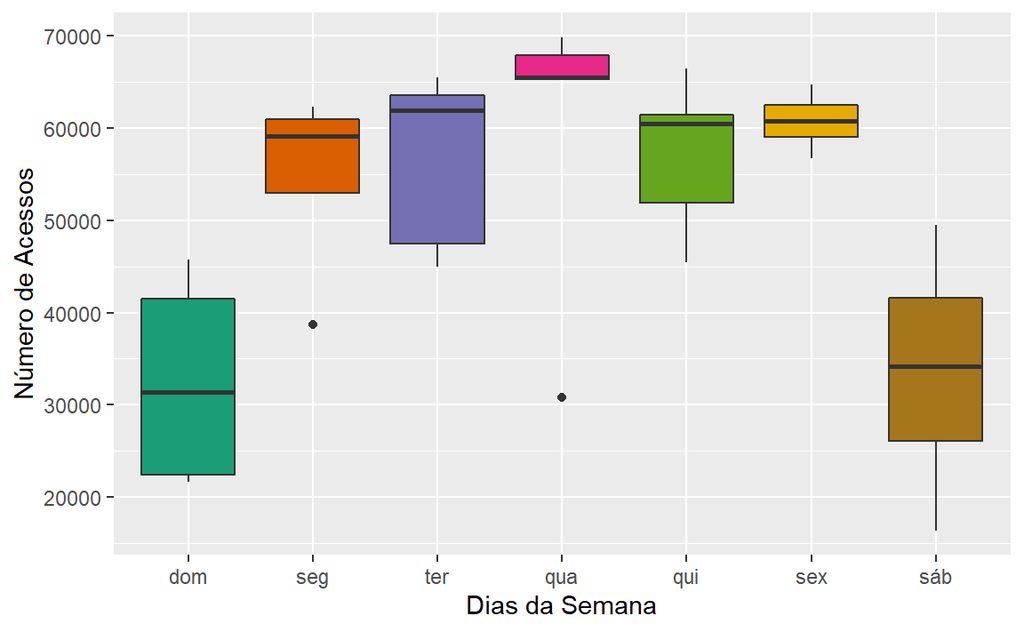

Pelo menos em Maio, quarta-feira foi o dia mais usado. Colocaria mais bicicletas na rua nestes dias.

# O que mais podemos saber sobre os usuários?

Independente do genêro, quarta-feira é o dia mais usado

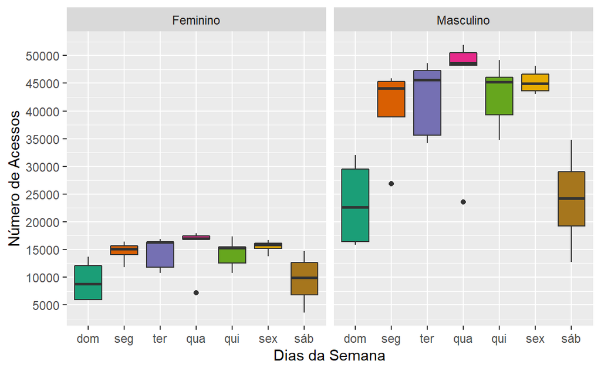

Independente da faixa etária, os homens foram os que mais usaram o serviço

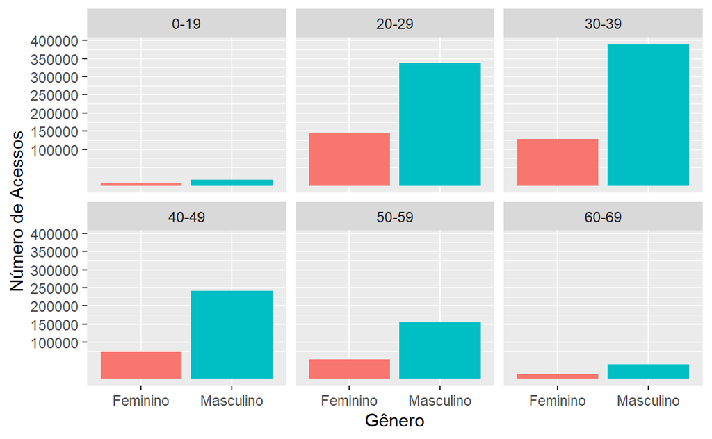

`Asssinantes`(*Subscriber*) além de utilizarem as bicicletas mais vezes que `clientes avulsos`(*Customer*), também utilizam mais nas quartas-feiras.

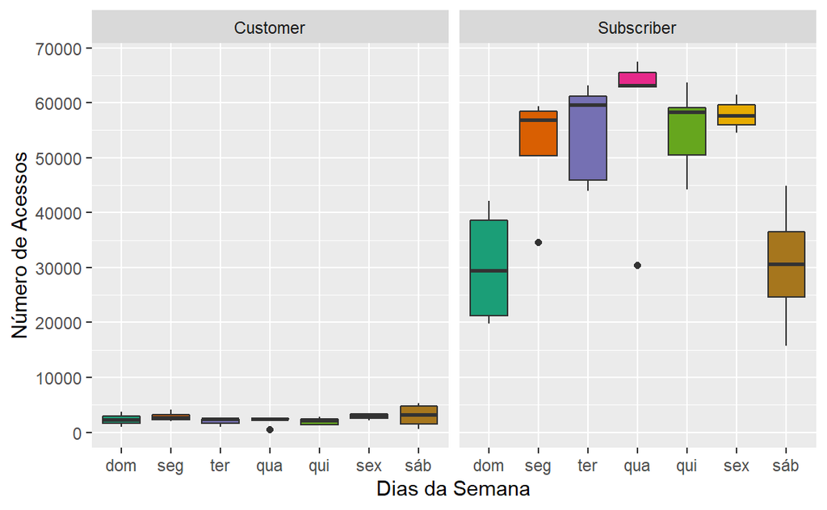

Curiosidade: Quando sou responsavél técnico em alguma drogaria (Sou farmacêutico de formação), é nítido a importância de um clinte fiel, que prefere consumir em sua drograria. Entretanto, este dataset deixa bem claro a diferença e como isso impacta os negocios e este [artigo](https://www.cratejoy.com/sell/blog/difference-between-subscriber-and-customer/) facilita o entendimento.

# As Estações.

Agora iremos avaliar quais são as estações que mais tiveram acesso dos usuário em todo mês de Maio.

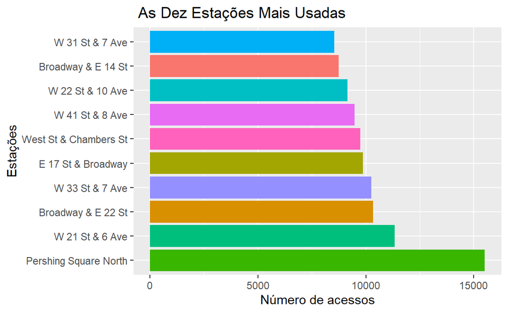

## Qual a mais estação mais utilizada na quarta?

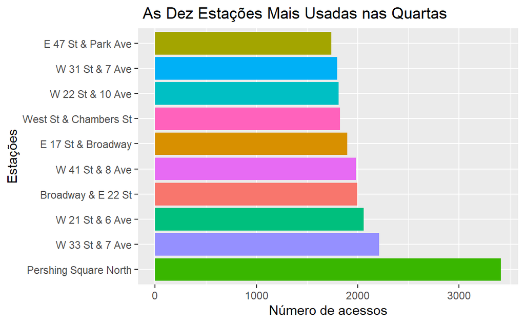

## Há variação pelo tipo de usuário?

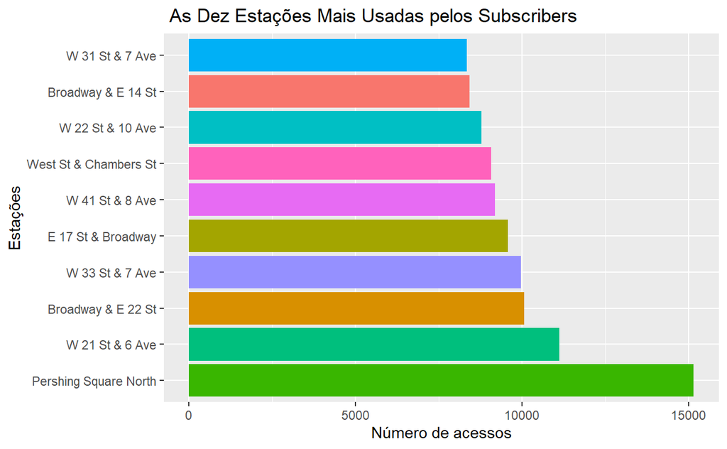

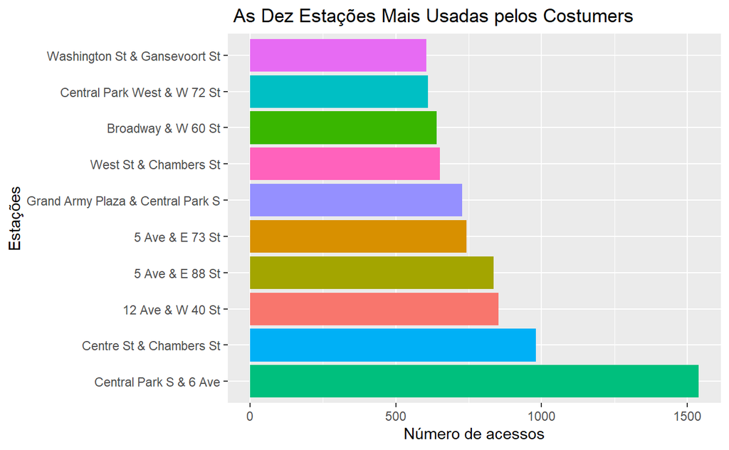

Vemos por essa última comparação que os consumidores avulsos tem utilizam estaçãos diferentes que os assinantes. Considerano que a mais uada pelos avulsos foi a do Central Park, eu imagino que sejá para passear por ele, apenas um achismos.

De quaquer forma, talvez seja valiada uma investigação mais profunda. E a partir do resultado, isto pode ser utilizado pelo marketing para alocação de propagrandas nestas estações, específicas para angariar mais inscrições ao programa.

# Conclusão

Tivemos uma visão geral qual é o perfil e consumidores dos usuários de biclicletas alugadas em Nova Iorque e possiveis insights que podem ajudar a equipe de negocios a tomar decisões melhores.